```python
%matplotlib inline
from matplotlib import pylab
```

# Obróbka danych w macierzach numpy

## Sortowanie

```python
import numpy as np
```

```python
random = np.random.random(10)
random
```

```
array([ 0.44760782,  0.48095597,  0.86307326,  0.91863612,  0.34832552,
        0.64402301,  0.68667868,  0.99873946,  0.1430979 ,  0.39522482])
```

```python
np.sort(random) # Działa jak sorted
```

```
array([ 0.1430979 ,  0.34832552,  0.39522482,  0.44760782,  0.48095597,
        0.64402301,  0.68667868,  0.86307326,  0.91863612,  0.99873946])
```

Powiedzmy że mamy tablicę N x 3, która zawiera wartości pewnej funkcji $R^2 \rightarrow R$ na zmierzone dla dwóch zestawu punktów. W pierwszej kolumnie jest wartość X dla każdego z N punktów, w drugiej Y w trzeciej wartość punktów. Chcemy teraz posortować tą tablicę względem wartości Y

```python
array = np.random.random((10, 3))
```

Do wykonania tej operacji służy funkcja `np.argsort` która zwraca indeksy które mają pozwalać na posortowanie tablicy.

```python
indeksy_sortujace = np.argsort(array[:, 1]) # Wybieramy tylko kolumnę z Y i dostajemy indeksy
```

```python
array[:, 1][indeksy_sortujace]
```

```
array([ 0.02246321,  0.03544397,  0.048845  ,  0.14415717,  0.16448422,
        0.26015029,  0.69152298,  0.71784117,  0.81128519,  0.81601787])
```

```python
array[indeksy_sortujace]
```

```
array([[ 0.3673974 ,  0.02246321,  0.9389421 ],
       [ 0.37814015,  0.03544397,  0.10350637],
       [ 0.96609645,  0.048845  ,  0.82967877],
       [ 0.78647026,  0.14415717,  0.10734441],
       [ 0.69124605,  0.16448422,  0.46878055],
       [ 0.99440606,  0.26015029,  0.67568401],
       [ 0.82590353,  0.69152298,  0.23067954],
       [ 0.5150773 ,  0.71784117,  0.01094984],
       [ 0.24122545,  0.81128519,  0.77709138],
       [ 0.95227789,  0.81601787,  0.8122437 ]])
```

## Maksimum, minimum

```python
random = np.random.random(10)
random
```

```
array([ 0.72602205,  0.063436  ,  0.1969681 ,  0.0193703 ,  0.77469882,
        0.31792851,  0.0729093 ,  0.75356195,  0.1643407 ,  0.99548451])
```

```python
np.max(random)
```

```
0.9954845112528754
```

```python
np.min(random)
```

```
0.019370299944439395
```

Tak samo jak `argsort`, `argmax` i `argmin` zwracają indeks pod którym znajduje się maksimum/minimum.

```python
np.argmax(random)
```

[output not shown]

```python
np.argmin(random)
```

[output not shown]

## Średnia, mediana

```python
np.mean(np.random.random(100))
```

```
0.49824223320776523
```

```python
np.median(np.random.random(100))
```

```
0.47354791733291124
```

```python
np.std(np.random.random(100))
```

```
0.30060804297777588
```

## Histogram

Funkcja np.histogram histogramuje dane i zwraca krotkę zawierającą wartości histogramu oraz brzegi binów histogramu.

```python
random_sum = np.sum(np.random.random((100, 1000)), axis=0)
```

```python
values, bin_edges = np.histogram(random_sum, )
```

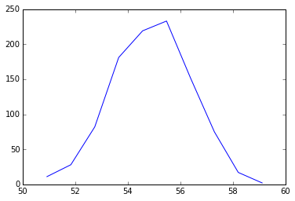

```python
pylab.plot((bin_edges[1:]+bin_edges[-1])/2, values)
```

## Znalezienie indeksów spełniających predykat

Funkcja `np.where` przyjmuje tablicę logiczną, jeśli ta tablica ma N wymiarów to `where` zwraca N tablic zawierających indeksy w ktróych tablica ta ma wartości prawdziwe

```python
random = np.random.random(10)
random
```

```
array([ 0.39063146,  0.75968786,  0.71910739,  0.85020937,  0.3606133 ,
        0.00850859,  0.32011255,  0.57668266,  0.84950912,  0.85569103])
```

```python
np.where(random<.5) #W tych indeksach tablica ta ma wartość mniej niż 0.5.
```

```
(array([0, 4, 5, 6]),)
```

```python
random2d = np.random.random((3, 3))
random2d
```

```
array([[ 0.45077819,  0.18317865,  0.76232586],
       [ 0.34793677,  0.89409347,  0.90550618],
       [ 0.56441239,  0.54799542,  0.25729542]])
```

```python
np.where(random2d<.7)  #W tych indeksach tablica ta ma wartość mniej niż 0.7.
```

```
(array([0, 0, 1, 2, 2, 2]), array([0, 1, 0, 0, 1, 2]))
```

Przykład zastosowania funkcji where to znalezienie pierwszego indeksu spełniającego predykat

```python
np.where(random<.5)[0][0]
```

```
0
```

## Przeszukiwanie

Funkcja `np.searchsorted` przyjmuje dwie tablice: jedną posortowaną A i drugą B i zwraca indeksy w pierwszej tablicy do przed (lub zależnie od opcji: za) które można wstawic elementy z B do A tak by A była ciągle posortowana

```python
data = np.arange(0, 2, .2)
```

```python
data
```

```
array([ 0. ,  0.2,  0.4,  0.6,  0.8,  1. ,  1.2,  1.4,  1.6,  1.8])
```

```python
to_be_inserted = [1.1, 1.2, 1.5, 0.5]
indices = np.searchsorted(data, to_be_inserted)
indices
```

```
array([6, 6, 8, 3])
```

```python
np.insert(data, indices, to_be_inserted)
```

```
array([ 0. ,  0.2,  0.4,  0.5,  0.6,  0.8,  1. ,  1.1,  1.2,  1.2,  1.4,
        1.5,  1.6,  1.8])
```

## Operacje na osiach

Sumowanie całej tablicy jest operacją o ograniczonej przydatności, zdecydowanie przytatniejsze byłoby sumowanie tablicy względem którejś osi.

Przykładowo mamy pewne zdarzenie jądrowe i otrzymujemy koordynaty cząstestek w geometrii kartezjańskiej. Chcę policzyć środek ciężkości chmury cząstek (które zakładamy mają masę równą 1).

Numpy w wielu operacjach pozwala na specyfikowanie osi "wzdłuż" której działa operacja.

```python
coords = np.random.random((1000, 3))
```

```python
coords
```

```
array([[ 0.83769849,  0.56890956,  0.56506461],
       [ 0.40502735,  0.43334184,  0.62774204],
       [ 0.45595799,  0.50242069,  0.66175362],
       ...,
       [ 0.03034786,  0.60686688,  0.15796221],
       [ 0.80641827,  0.93326945,  0.04504715],
       [ 0.02338288,  0.16877554,  0.14206055]])
```

```python
np.average(coords) # Średni koordynat nie ma sensu!
```

```
0.49911934702856525
```

```python
np.average(coords, axis=0) # Operacja average działa wzdłuż osi 1, czyli osi definiowanej pierwszym wymiarem tablicy.
```

```
array([ 0.50149494,  0.49847956,  0.49738354])
```

```python
np.average(coords, axis=1).shape # To też nie ma sensu fizycznego!
```

```
(1000,)
```